### My course project in the Developing Data Products

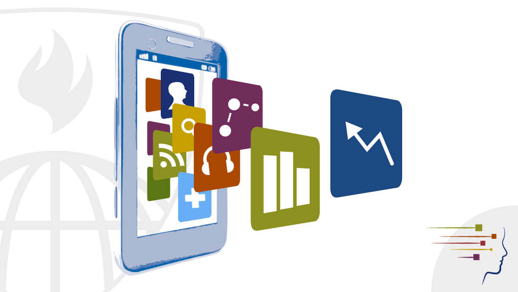

### Course Description

This folder contains my course project submitted through GitHub for the course Developing Data Products in Coursera. This is the ninth course in the Johns Hopkins Data Science Specialization.

### Course Requirement

This peer assessed assignment has two parts. First, the student is required to create a Shiny application and deploy it on Rstudio’s servers. Second, the student will use Slidify or Rstudio Presenter to prepare a reproducible pitch presentation about the application.

My Shiny application [Comparing Algorithms](https://docofi.shinyapps.io/ShinyApp10/)

My pitch presentation [Comparing Algorithms - Guide to the App](http://rpubs.com/DocOfi/170100)

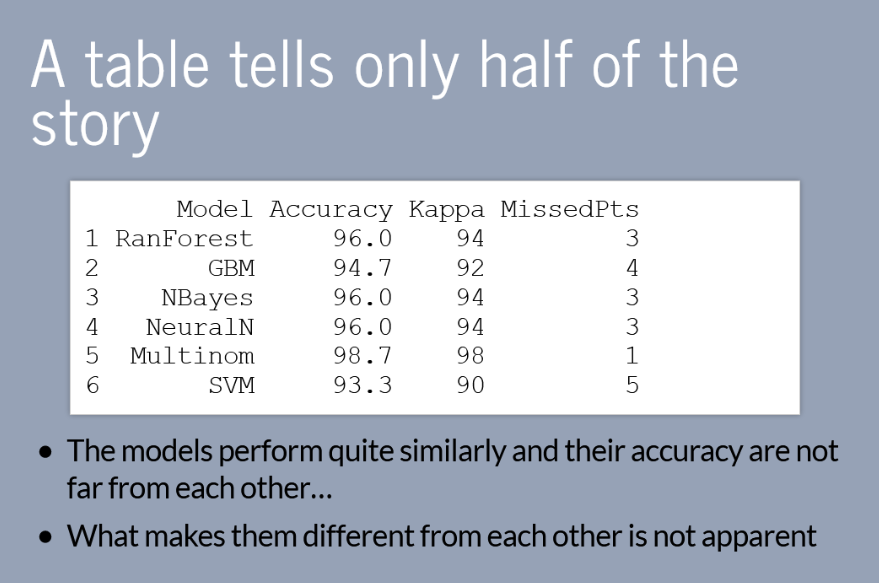

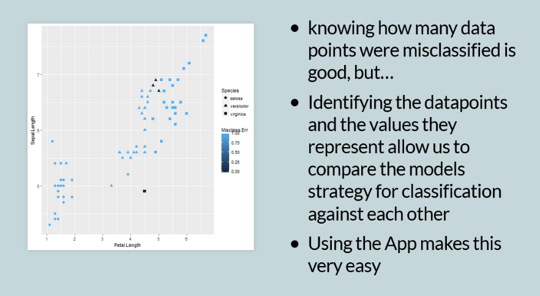

### Content

This folder contains the following:

- A ReadMe markdown document
- A Miscerr.Rpres document
- A Miscerr-figure folder
- A ose.csv file
- A ui.R file
- A server.R file
- image1.png
- image2.png

The README markdown document is displayed by default by GitHub whenever you visit a GitHub repository. The document you are reading now is the README.md file. It Tcontains information about the content of this repo.

The Miscerr.Rpres is the RStudio presenter file that created the pitch presenetation. To view the pitch presentation click on [Comparing Algorithms - Guide to the App](http://rpubs.com/DocOfi/170100)

The Miscerr-figure is the folder that contains the images included in the pitch presentation.

The ose.csv file is the data file in .csv format which contained data for the pitch presentation

The .png files are images that are displayed in the README.md document.